# R - Animation

## Animating raster data(a bit of bodge)

```r
library(terra)
```

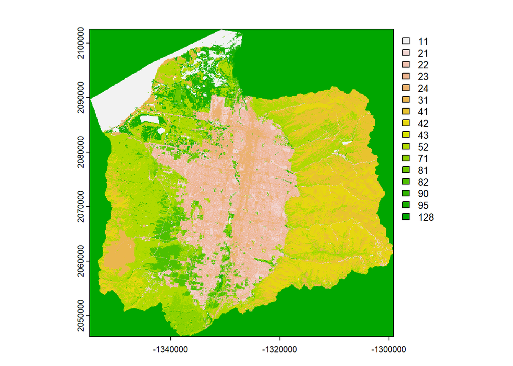

```r
SL_2001<-as.factor(rast("NLCD_2001_SL.tif"))
SL_2004<-as.factor(rast("NLCD_2004_SL.tif"))
SL_2006<-as.factor(rast("NLCD_2006_SL.tif"))
SL_2008<-as.factor(rast("NLCD_2008_SL.tif"))
SL_2011<-as.factor(rast("NLCD_2011_SL.tif"))
SL_2013<-as.factor(rast("NLCD_2013_SL.tif"))
SL_2016<-as.factor(rast("NLCD_2016_SL.tif"))
plot(SL_2001)
```

20. Here, we are assigning names to different classes, which will allow us to create a legend and apply a NLCD (National Land Cover Database) color palette to the data. To achieve this, we need to create a table that lists the values in the raster along with their corresponding names. Once this table is prepared, we can use the levels() function to apply these names to all the layers in the raster. This process is essential for visualizing and interpreting the data effectively.

```r
value <- levels(SL_2001)[[1]]$ID
landcoverDesc <- c("Open Water", "Developed, Open Space", "Developed, Low Intensity", "Developed, Medium Intensity", "Developed, High Intensity","Barren Land (Rock/Sand/Clay)","Deciduous Forest", "Evergreen Forest", "Mixed Forest","Scrub/Shrub","Grassland/Herbaceous","Pasture/Hay", "Cultivated Crops", "Woody Wetlands","Emergent Herbaceous Wetlands", "NA")

cls <- data.frame(value, landcoverDesc)

levels(SL_2001)<-levels(SL_2004)<-levels(SL_2006)<-levels(SL_2008)<-levels(SL_2011)<-levels(SL_2013)<-levels(SL_2016)<-cls
```

21. We need to apply colors to the raster like the names. Here we use `coltab()`

```r
##I defined the colors for the nlcd data. This works for the values (classes) in Salt Lake
colors <- c("#476BA0","#DDC9C9","#D89382","#ED0000", "#AA0000","#B2ADA3","#68AA63", "#1C6330","#B5C98E", "#CCBA7C", "#E2E2C1", "#DBD83D", "#AA7028", "#BAD8EA","#70A3BA", "#FFFFFF"
  )

col <- data.frame(value, colors)

coltab(SL_2001)<-coltab(SL_2004)<-coltab(SL_2006)<-coltab(SL_2008)<-coltab(SL_2011)<-coltab(SL_2013)<-coltab(SL_2016)<-col
```

22. Finally, we are using the `animate()` function to loop through the separate maps. To do this, we need to stack the raster on top of one anther using `c()`.

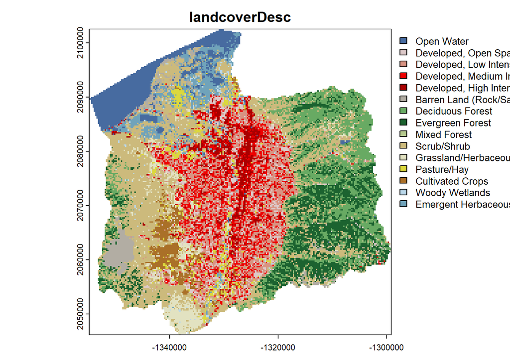

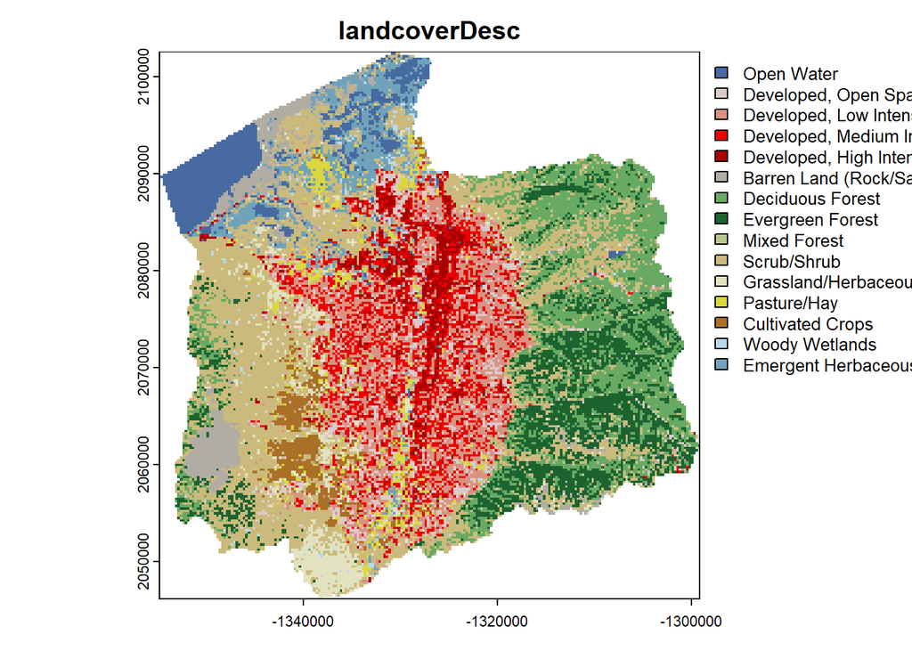

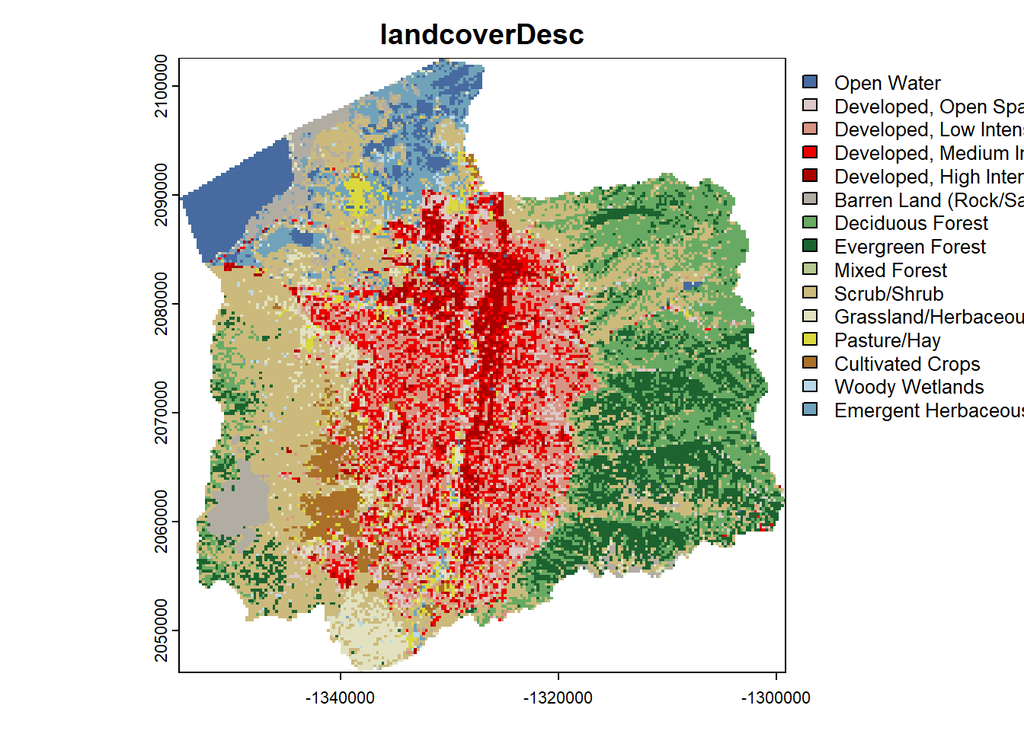

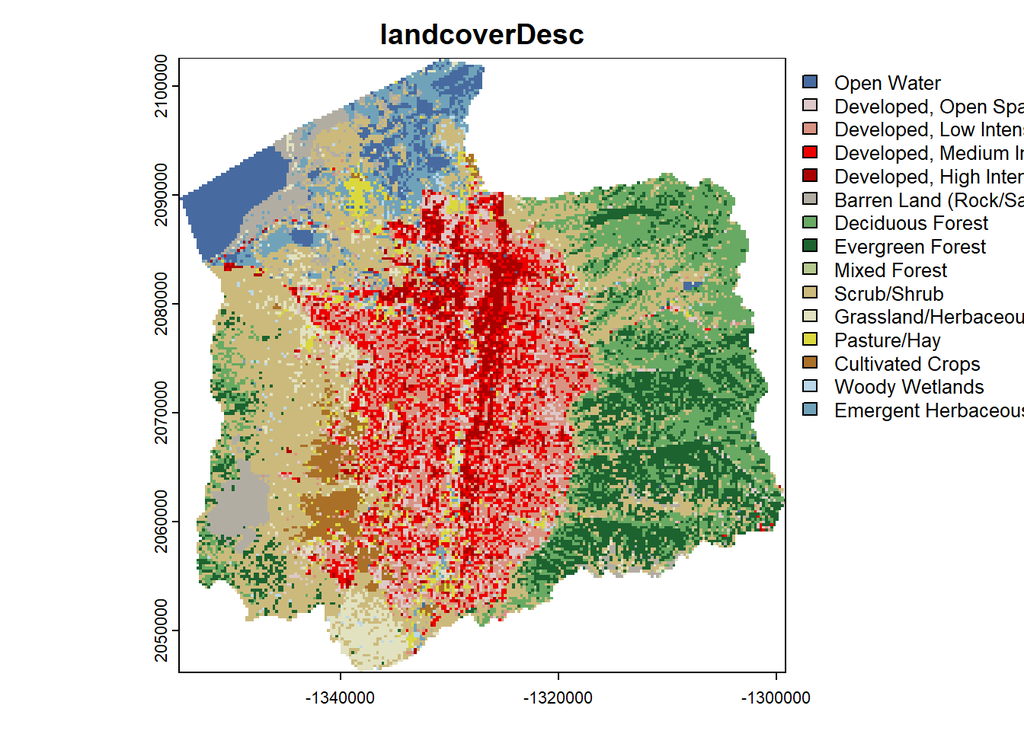

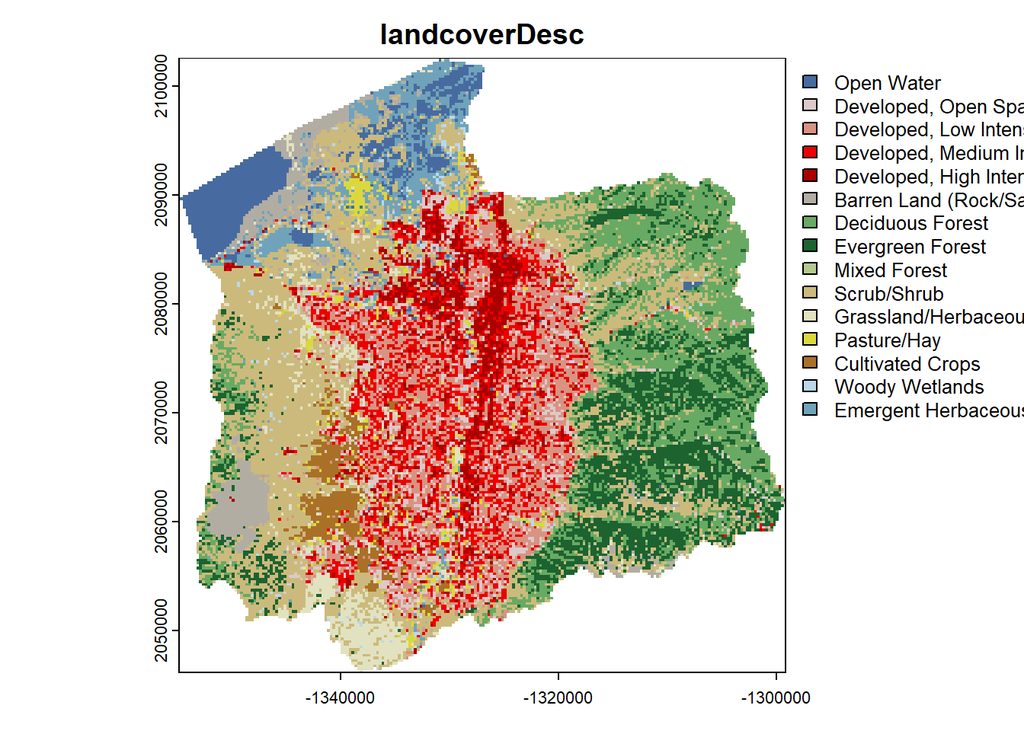

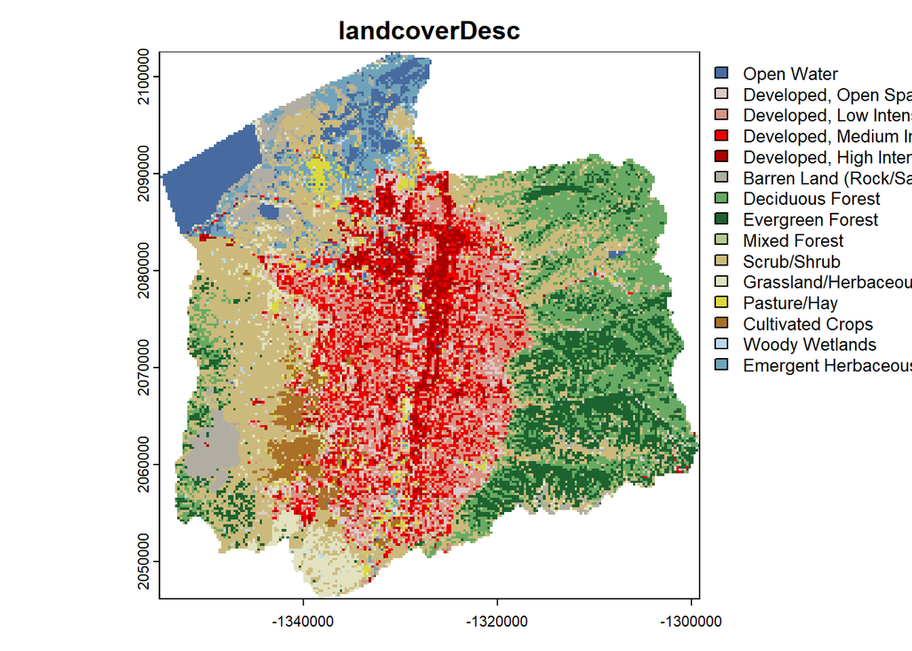

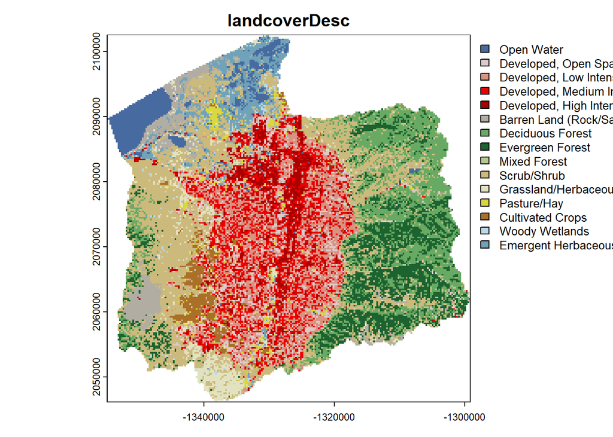

```r
rasterStack<- c(SL_2001, SL_2004,SL_2006, SL_2008, SL_2011,SL_2013, SL_2016)
#names(rasterStack) <- c("LU 2001", "LU 2004", "LU 2006" , "LU 2008", "LU 2011","LU 2013", "LU2016")

animate(rasterStack,pause=0.25)
```